# GWAS on severe asthma: genetic tests comparison

Noemi Nicole Piga

20 April, 2023

```r
#library reticulate to be able to add chuncks in another language
library(reticulate)
library(knitr)
```

```bash
# To run this .rmd file in a terminal being in the project folder:
module unload R/4.2.1
module load R/4.1.0
export PATH=${PATH}:/cm/shared/apps/R/deps/rstudio/bin/pandoc
file="./report/GWAS_SA_genetictests_comparison.Rmd"
module unload R/4.2.1
module load R/4.1.0
Rscript -e 'rmarkdown::render("'$file'")'
```

# Rationale

Run recessive and dominant genetic test models for GWAS of severe asthma individuals and compare the result with the additive model.  
Historically, additive model is the most used for GWAS due to its value to pick more variants with small effects. However, in the last years, researchers have started to use the other genetic tests and to compare the results.  
We decide to do the same with our 46,086 individuals of European ancestry with severe asthma in UK Biobank.

# Analysis

Run REGENIE association analysis with the three different model: same parameters, except for ‘–test’, which was changed everytime according to the test type. Additive is the default, ‘recessive’ and ‘dominant’ are the other two options.  
All the three analyses started from 46,086 total individuals: 7,681 cases and 38,405 controls.  
Number of analysed variants changed for the different tests:

- additive: 34,396,871
- recessive: 14,334,721
- dominant: 34,297,344

I then retained results for variants with minor allele frequency (MAF) equal or greater than 0.01. These variants were used to calculate linkage disequilibrium score regression (LDSC) intercept, as measure of genomic inflation; obtain Q-Q plot and Manhattan plot; find sentinel variants and calculate odds ratio.  
The code used is the same presented in ‘GWAS > Association Analysis’. Additionally here, I used a script to create Miami plot.  
Code: src/broad_phenotype/Miami_plot.R

```r
#!/usr/bin/env R

library(tidyverse)
library(data.table)
library(hudson)

#args = commandArgs(trailingOnly=TRUE)

#Run it as:
#Rscript output/maf001_broad_pheno_1_5_ratio_betase_input_mungestat output/maf001_broad_pheno_female_betase_input_mungestat "broad_pheno" "broad_pheno_female"
#Rscript output/maf001_broad_pheno_1_5_ratio_betase_input_mungestat output/maf001_broad_pheno_male_betase_input_mungestat "broad_pheno" "broad_pheno_male"
#Rscript output/maf001_broad_pheno_female_betase_input_mungestat output/maf001_broad_pheno_male_betase_input_mungestat "broad_pheno_female" "broad_pheno_male"
#Rscript output/maf001_broad_pheno_childhoodonset_betase_input_mungestat output/maf001_broad_pheno_adultonset_betase_input_mungestat "broad_pheno_childhoodonset" "broad_pheno_adultonset"
#Rscript output/maf001_broad_pheno_1_5_ratio_betase_input_mungestat output/maf001_noallergy_pheno_betase_input_mungestat "broad_pheno" "broad_pheno_noallergy"
#Rscript output/maf001_broad_pheno_1_5_ratio_betase_input_mungestat output/maf001_broad_pheno_1_5_ratio_array_betase_input_mungestat "broad_pheno" "broad_pheno_array"
#Rscript output/maf001_broad_pheno_1_5_ratio_betase_input_mungestat output/maf001_broad_pheno_1_5_ratio_dominant_betase_input_mungestat "broad_pheno" "broad_pheno_dominant"
#Rscript output/maf001_broad_pheno_1_5_ratio_betase_input_mungestat output/maf001_broad_pheno_1_5_ratio_recessive_betase_input_mungestat "broad_pheno" "broad_pheno_recessive"

sumstat1_file <- "output/maf001_broad_pheno_1_5_ratio_betase_input_mungestat"
sumstat2_file <- "output/maf001_broad_pheno_1_5_ratio_recessive_betase_input_mungestat"
pheno1 <- "broad_pheno"
pheno2 <- "broad_pheno_recessive"

#sumstat1_file <- args[1]
#sumstat2_file <- args[2]
#pheno1 <- args[3]
#pheno2 <- args[4]

sumstat1 <- fread(sumstat1_file,header=T) %>% select('snpid','b37chr','bp','pval')

sumstat2 <- fread(sumstat2_file,header=T) %>% select('snpid','b37chr','bp','pval')

colnames(sumstat1) <- c("SNP","CHR","BP","P")
colnames(sumstat2) <- c("SNP","CHR","BP","P")

sumstat1$P <- as.numeric(sumstat1$P)
sumstat2$P <- as.numeric(sumstat2$P)
sumstat1 <- sumstat1 %>% filter(P < 0.05 ) %>% rename(POS = BP,pvalue = P)
sumstat2 <- sumstat2 %>% filter(P < 0.05 ) %>% rename(POS = BP,pvalue = P)

top_title_name <- paste0(pheno1)
bottom_title_name <- paste0(pheno2)
file_name <- paste0('output/Miami_plot_Eur_UKBB','_',pheno1,'_VS_',pheno2)
gmirror(top=sumstat1, bottom=sumstat2, tline=5E-08, bline=5E-08, toptitle=top_title_name, bottomtitle=bottom_title_name, file=file_name)
```

I compared the effect size of the sentinel variants of the additive model with the other two models. In addition, I looked at variants with MAF < 0.01 to see if their effect size and/or p-value changed with regards to different methods.  
Code : src/broad_phenotype/comparison_genetic_test.R

```r
#!/usr/bin/env Rscript


module unload R/4.2.1
module load R/4.1.0

suppressMessages(library(tidyverse))
suppressMessages(library(data.table))

#filter out additive test's sentinel variants
x_dominant <- 'cut -f 1-5 output/maf001_broad_pheno_1_5_ratio_sentinel_variants.txt | grep -F -f - output/maf001_broad_pheno_1_5_ratio_dominant_betase_input_mungestat > output/additive_sentinel_in_dominant'
system(x_dominant)

x_recessive <- 'cut -f 1-5 output/maf001_broad_pheno_1_5_ratio_sentinel_variants.txt | grep -F -f - output/maf001_broad_pheno_1_5_ratio_recessive_betase_input_mungestat > output/additive_sentinel_in_recessive'
system(x_recessive)

additive <- fread("output/maf001_broad_pheno_1_5_ratio_sentinel_variants.txt")
dominant <- fread("output/additive_sentinel_in_dominant")
recessive <- fread("output/additive_sentinel_in_recessive")

additive$test <- as.factor("additive")
dominant$test <- as.factor("dominant")
recessive$test <- as.factor("recessive")

add_dom <- rbind(additive,dominant)
add_dom_rec <- rbind(add_dom,recessive)

#create odds_ratio ci_lower ci_upper
add_dom_rec$odds_ratio <- exp(add_dom_rec$LOG_ODDS)
add_dom_rec$ci_lower <- exp(add_dom_rec$LOG_ODDS - qnorm(0.975)*add_dom_rec$se)
add_dom_rec$ci_upper <- exp(add_dom_rec$LOG_ODDS + qnorm(0.975)*add_dom_rec$se)

add_dom_rec$test <- as.factor(add_dom_rec$test)

#plot OR for the different tests:
or_plot <- add_dom_rec %>% ggplot(aes(x = snpid, y = odds_ratio, color = test)) +
  geom_boxplot(position=position_jitterdodge()) + geom_errorbar(aes(ymin = ci_lower, ymax = ci_upper), position = "dodge") +
  theme(axis.text.x = element_text(angle = 45, vjust = 1, hjust = 1))

#and save plot:
ggsave("output/OR_sentinel_genetic_test_boxplot.png",or_plot,width = 11, height = 8)

#plot p-value:
pval_plot <- add_dom_rec %>% ggplot(aes(x = snpid, y = -log10(pval), color = test)) +
  geom_point() +
  geom_hline(yintercept=7.3, linetype="dashed", color = "black") +
  theme(axis.text.x = element_text(angle = 45, vjust = 1, hjust = 1))

#and save plot:
ggsave("output/pval_sentinel_genetic_test_plot.png",pval_plot,width = 11, height = 8)

#compare variants with maf < 0.01
columns = c("snpid", "b37chr", "bp", "a1", "a2", "LOG_ODDS", "se", "eaf", "LOG10P", "MAF", "test")
add_dom_rec_aboveMAF001 = data.frame(matrix(nrow = 0, ncol = length(columns)))
colnames(add_dom_rec_aboveMAF001) = columns

for (i in c("_", "_dominant", "_recessive")){
df_file <- paste0("output/allchr/broad_pheno_1_5_ratio",i,"allchr.assoc.txt.gz")
df <- fread(df_file,header=F)
#CHROM GENPOS ID ALLELE0 ALLELE1 A1FREQ INFO N TEST BETA SE CHISQ LOG10P
#REGENIE: reference allele (allele 0), alternative allele (allele 1)
#REGENIE:  estimated effect sizes (for allele 1 on the original scale)
colnames(df) <- c("CHROM", "GENPOS", "ID", "ALLELE0", "ALLELE1", "A1FREQ", "INFO", "N","TEST", "BETA", "SE", "CHISQ", "LOG10P")
df <- df %>% select(CHROM,ID,GENPOS,ALLELE1,ALLELE0,A1FREQ,LOG10P,BETA,SE,TEST)
#select column in order:
df <- df %>% select(ID,CHROM,GENPOS,ALLELE1,ALLELE0,BETA,SE,A1FREQ,LOG10P, TEST)
#rename columns :
colnames(df) <- c("snpid", "b37chr", "bp", "a1", "a2", "LOG_ODDS", "se", "eaf", "LOG10P", "test")
df <- df %>% mutate(MAF = ifelse(df$eaf <= 0.5, df$eaf, 1 - df$eaf))
df_above_MAF001 <- df %>% filter(MAF < 0.01)
add_dom_rec_aboveMAF001 <- rbind(add_dom_rec_aboveMAF001,df_above_MAF001)
}

add_dom_rec_aboveMAF001$test <- as.factor(add_dom_rec_aboveMAF001$test)

#plot MAF by test:
maf_plot <- ggplot(add_dom_rec_aboveMAF001, aes(x=MAF)) + geom_histogram(position="identity", alpha=0.5) + facet_grid(~test)
#and save plot:
ggsave("output/MAF_genetic_test_histplot.png",maf_plot,width = 11, height = 8)

#plot p-val by test:
pval_plot <- ggplot(add_dom_rec_aboveMAF001, aes(x=-LOG10P)) + geom_histogram(position="identity", alpha=0.5) + facet_grid(~test)
#and save plot:
ggsave("output/pval_genetic_test_histplot.png",pval_plot,width = 11, height = 8)
```

# Results

The number of analysed variants with MAF > 0.01 is:

- additive: 9,804,778
- recessive: 9,804,101
- dominant: 9,804,755

## Recessive

I obtained ldsc intercept of 1.01 and Q-Q plot as shown below (Fig. 1):

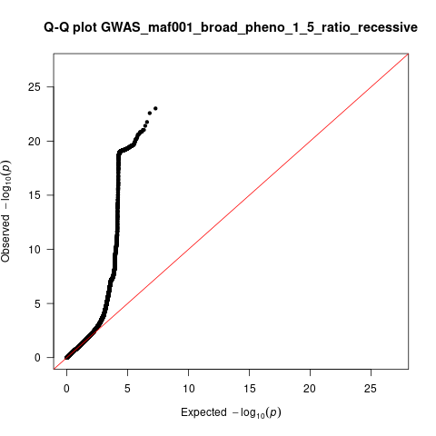

Fig1. Q-Q plot recessive genetic test

Twelve sentinel variants and loci were identified (Table 1), visible in the Manhattan plot (Fig. 2):

Table 1. Sentinel variants recessive test

| SNP | Chr | Position (GRCh37) | Effect allele | Non effect allele | Effect allele frequency | OR [95%CI] | P-value | Direction of effect |
| --- | --- | --- | --- | --- | --- | --- | --- | --- |
| rs77433658 | 2 | 242693421 | T | C | 0.243010 | 0.73 [0.65-0.82] | 0 | - |
| rs1837253 | 5 | 110401872 | C | T | 0.740095 | 1.23 [1.17-1.29] | 0 | + |
| rs848 | 5 | 131996500 | C | A | 0.817515 | 0.83 [0.79-0.88] | 0 | - |
| rs9274306 | 6 | 32632006 | G | T | 0.560694 | 1.32 [1.25-1.39] | 0 | + |
| rs2523572 | 6 | 31329494 | T | C | 0.646487 | 1.23 [1.17-1.29] | 0 | + |
| rs6462 | 6 | 32006597 | T | C | 0.724021 | 1.16 [1.10-1.22] | 0 | + |
| rs6473228 | 8 | 81299766 | T | G | 0.633334 | 0.86 [0.82-0.91] | 0 | - |
| rs992969 | 9 | 6209697 | G | A | 0.747448 | 0.83 [0.79-0.88] | 0 | - |
| 10:9041059_AT_A | 10 | 9041059 | A | AT | 0.830411 | 0.82 [0.78-0.87] | 0 | - |
| rs10160518 | 11 | 76296671 | G | A | 0.503249 | 1.19 [1.13-1.26] | 0 | + |
| rs773107 | 12 | 56369506 | G | A | 0.334332 | 1.25 [1.16-1.35] | 0 | + |
| 17:38073838_CCG_C | 17 | 38073838 | C | CCG | 0.409143 | 1.29 [1.20-1.38] | 0 | + |

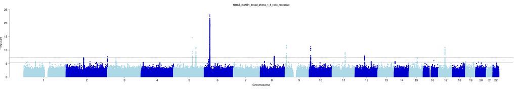

Fig2. Manhattan plot recessive genetic test

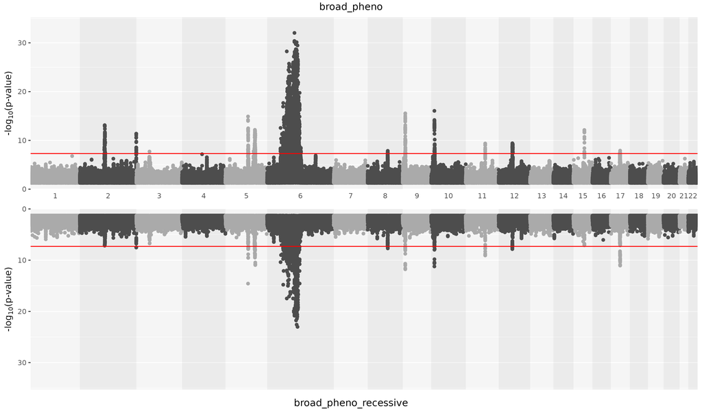

## Dominant

I obtained ldsc intercept of 1.01 and Q-Q plot as shown below (Fig. 4):

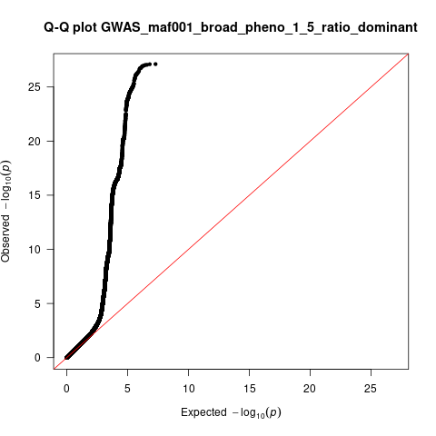

Fig4. Q-Q plot dominant genetic test

Fifteen sentinel variants and loci were identified (Table 2), visible in the Manhattan plot (Fig. 5):

Table 2. Sentinel variants dominant test

| SNP | Chr | Position (GRCh37) | Effect allele | Non effect allele | Effect allele frequency | OR [95%CI] | P-value | Direction of effect |
| --- | --- | --- | --- | --- | --- | --- | --- | --- |
| rs1420101 | 2 | 102957716 | T | C | 0.3853990 | 1.20 [1.14-1.26] | 0 | + |
| rs1106639 | 2 | 242690675 | A | G | 0.2526470 | 0.86 [0.82-0.90] | 0 | - |
| rs75636118 | 4 | 86621713 | T | C | 0.0434731 | 1.28 [1.18-1.39] | 0 | + |
| rs10455025 | 5 | 110404999 | C | A | 0.3565130 | 1.24 [1.18-1.31] | 0 | + |
| rs736801 | 5 | 131833599 | T | C | 0.3859620 | 0.85 [0.80-0.89] | 0 | - |
| rs152815 | 5 | 131026218 | A | G | 0.3878140 | 0.86 [0.82-0.91] | 0 | - |
| rs9271579 | 6 | 32590637 | A | T | 0.2036940 | 1.33 [1.27-1.40] | 0 | + |
| rs2844518 | 6 | 31372569 | T | C | 0.3699460 | 1.23 [1.17-1.30] | 0 | + |
| rs1150755 | 6 | 32038550 | T | C | 0.1732520 | 1.18 [1.12-1.24] | 0 | + |
| rs144829310 | 9 | 6208030 | T | G | 0.1625020 | 1.22 [1.15-1.28] | 0 | + |
| rs12413578 | 10 | 9049253 | T | C | 0.1052380 | 0.76 [0.71-0.82] | 0 | - |
| rs324011 | 12 | 57502182 | T | C | 0.4158510 | 1.19 [1.13-1.25] | 0 | + |
| rs1131017 | 12 | 56435929 | G | C | 0.5705050 | 0.83 [0.78-0.89] | 0 | - |
| rs17293632 | 15 | 67442596 | T | C | 0.2369160 | 1.18 [1.12-1.24] | 0 | + |
| rs35196450 | 17 | 38062942 | AC | A | 0.4694940 | 0.83 [0.78-0.87] | 0 | - |

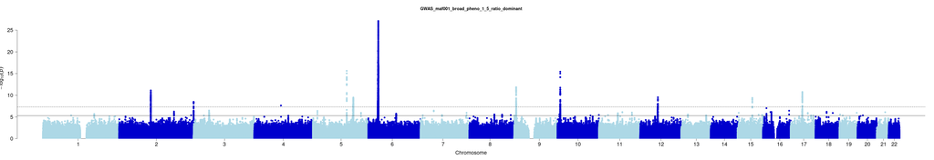

Fig5. Manhattan plot dominant genetic test

Miami plot between additive and dominant genetic test (Fig. 6):

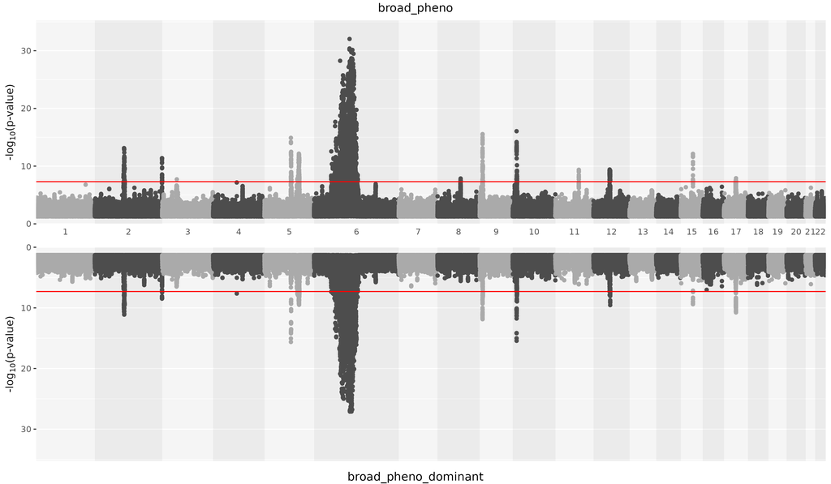

## Comparison between the three tests

### Sentinel variants

The different genetic tests show concordance of direction of effect for the sentinel variants found by the additive test (Fig.7). Some variants are not significant in the recessive or dominant tests.

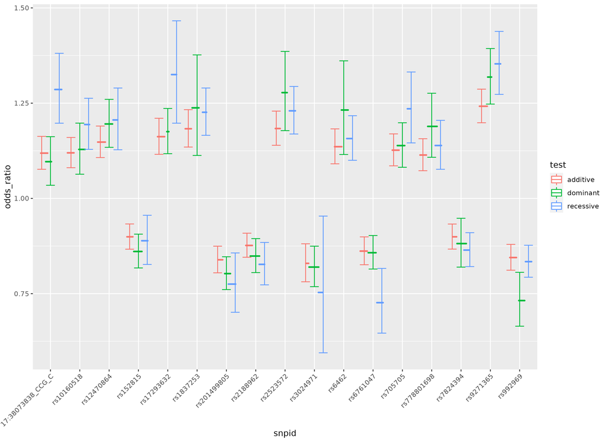

Fig7. Box plot effect size sentinel variants among different genetic tests

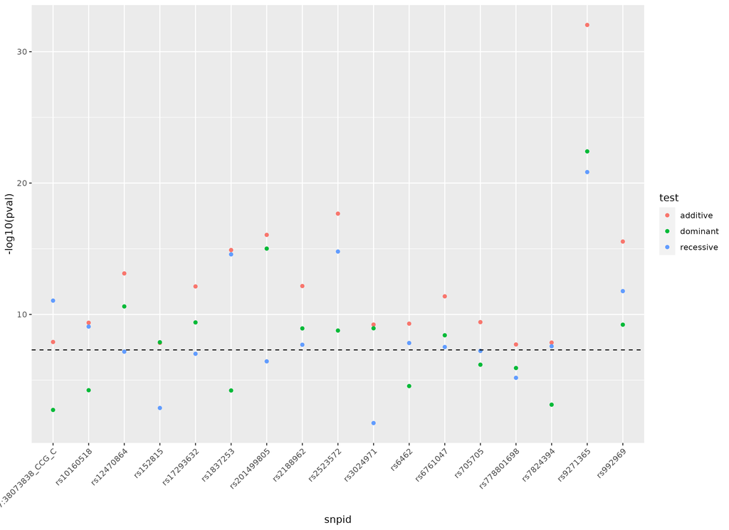

Fig8. P-value of sentinel variants among different genetic tests

### Variants with MAF < 0.01

Recessive test have a reduced number of variants with MAF < 0.01 (Fig.9), whereas the dominant model has a comparable number with the additive test:

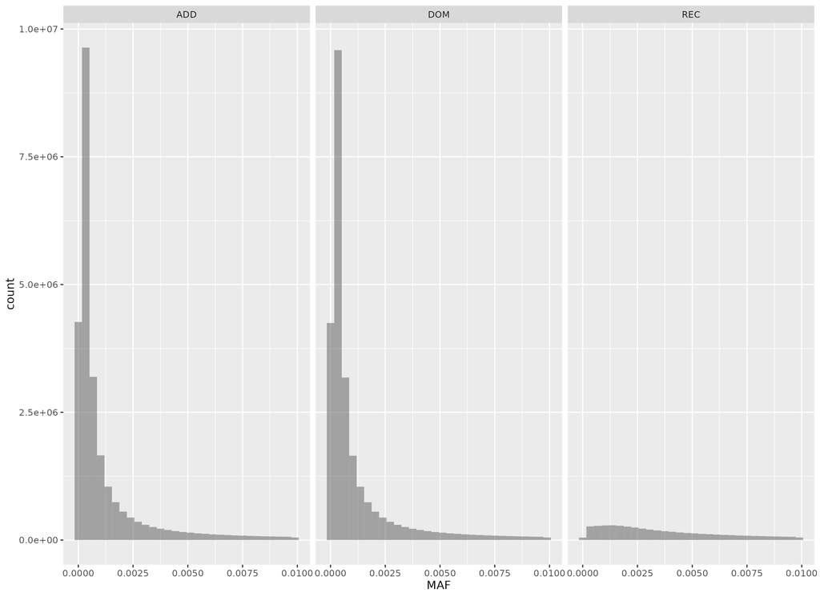

Fig8. Histogram plot of variants with MAF < 0.01 among different genetic tests

These variants do not show significant p-value in any test (Fig.10):

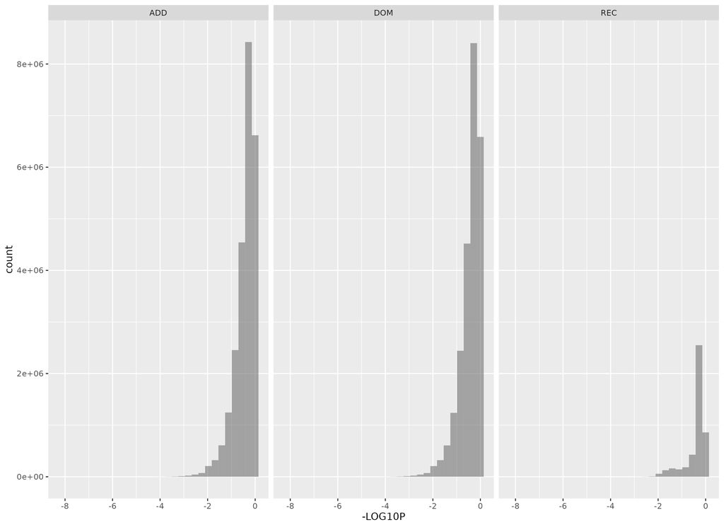

Fig9. Histogram plot of p-value (-log10(p-value)) for variants with MAF < 0.01 among different genetic tests

# Conclusion

The number of variants analysed by REGENIE changed according to the type of genetic test: the recessive model is the one with the lowest number of variants, while the additive and the dominant are pretty comparable. Anyway, the number of variants after MAF filtering is pretty much the same; this step is independent by the software and it happened after the REGENIE analysis.  
All the three tests shared the majority of significant loci, in some cases with the same sentinel variants, in others with a different one. The dominant model revealed a genome-wide significant locus on chromosome 4, which is just below the genome-wide significant in the additive one (Fig. 6).  
Neither the recessive nor the dominant showed evidence of genome-wide significance for the locus on chromosome 3, although it is below suggestive threshold of 5 x 10-6 for the dominant test (rs778801698: dominant p-value 1.20 x 10-6, recessive p-value 6.69 x 10-6).  
Regarding direction of effect: the recessive test showed concordance of effect for all sentinel, while the dominant test showed four sentinels with opposite direction, though, they are different sentinels from the ones found in the additive analysis. When looking at the sentinel variants for the additive test, both the recessive and the dominant tests show concordance of direction.  
Variants with MAF < 0.01 did not add any significant new results to the analysis.